# Boardgame data analysis

I downloaded data on all the boardgames I own from boardgamegeek.com and combined it with my own data (price I paid, my rating) so as to explore the data and pull out any patterns.

In this notebook I will also build a model to explain and predict my rating of a game based on several potential predictors.

```r
library(tidyverse)
library(broom)

bg_data <- read_csv("clean_data/boardgames_clean.csv")
bg_data
```

| boardgame | average_bgg_rating | average_difficulty | bgg_rank | num_owned | play_time | max_players | min_players | rec_age_range_from | average_players | price_i_paid | my_rating | year_bought |
| --- | --- | --- | --- | --- | --- | --- | --- | --- | --- | --- | --- | --- |
| 7 Wonders Duel | 8.09901 | 2.2261 | 18 | 140451 | 30 | 2 | 2 | 10 | 2.0 | 18 | 9 | 2022 |
| A Game Of Thrones: The Board Game (Second Edition) | 7.54716 | 3.7220 | 184 | 45898 | 240 | 6 | 3 | 14 | 4.5 | 40 | NA | 2014 |
| A War Of Whispers | 7.35921 | 2.5248 | 864 | 5810 | 60 | 4 | 2 | 12 | 3.0 | 34 | 7 | 2021 |
| Back To The Future: Back In Time | 7.26414 | 2.3871 | 1292 | 6587 | 50 | 4 | 2 | 8 | 3.0 | 32 | 8 | 2021 |
| Bang! The Dice Game | 6.90757 | 1.2795 | 733 | 37415 | 15 | 8 | 3 | 8 | 5.5 | 17 | 5 | 2018 |
| Batman: The Animated Series Adventures | 8.12519 | 3.4828 | 3545 | 1596 | 90 | 5 | 1 | 12 | 3.0 | 97 | NA | 2021 |
| Bears Vs Babies | 5.43756 | 1.2526 | 24508 | 12871 | 20 | 5 | 2 | 8 | 3.5 | NA | 6 | 2018 |
| Bilder | 6.75184 | 2.0000 | 11823 | 173 | 60 | 12 | 2 | 8 | 7.0 | 47 | 7 | 2020 |
| Burgle Bros 2: The Casino Capers | 7.37987 | 2.4865 | 1655 | 4909 | 70 | 4 | 1 | 10 | 2.5 | 37 | 8 | 2021 |
| Canvas | 7.33133 | 1.6471 | 465 | 18300 | 30 | 5 | 1 | 8 | 3.0 | 44 | 7 | 2021 |

[output cut: 47 more lines]

# What are the best and worst games I own according to me and according to Boardgamegeek?

```r
bg_data %>%
  slice_max(my_rating)
```

| boardgame | average_bgg_rating | average_difficulty | bgg_rank | num_owned | play_time | max_players | min_players | rec_age_range_from | average_players | price_i_paid | my_rating | year_bought |
| --- | --- | --- | --- | --- | --- | --- | --- | --- | --- | --- | --- | --- |
| Everdell: The Complete Collection | 8.88292 | 3.0000 | 31 | 8148 | 120 | 6 | 1 | 14 | 3.5 | 182 | 10 | 2022 |
| Root | 8.08015 | 3.7723 | 29 | 68243 | 90 | 4 | 2 | 12 | 3.0 | 116 | 10 | 2020 |
| Sleeping Gods | 8.30626 | 3.2277 | 55 | 22032 | 120 | 4 | 1 | 10 | 2.5 | 85 | 10 | 2021 |

Yep, these are some excellent games.

```r
bg_data %>%
  slice_min(my_rating)
```

| boardgame | average_bgg_rating | average_difficulty | bgg_rank | num_owned | play_time | max_players | min_players | rec_age_range_from | average_players | price_i_paid | my_rating | year_bought |
| --- | --- | --- | --- | --- | --- | --- | --- | --- | --- | --- | --- | --- |
| Gorilla Marketing | 7.15259 | 1.4 | 6275 | 485 | 40 | 8 | 3 | 14 | 5.5 | 23 | 3 | 2022 |

This makes sense. I sincerely regret buying Gorilla Marketing. Strange, strange game.

```r
bg_data %>%
  slice_max(average_bgg_rating)
```

| boardgame | average_bgg_rating | average_difficulty | bgg_rank | num_owned | play_time | max_players | min_players | rec_age_range_from | average_players | price_i_paid | my_rating | year_bought |
| --- | --- | --- | --- | --- | --- | --- | --- | --- | --- | --- | --- | --- |
| Everdell: The Complete Collection | 8.88292 | 3 | 31 | 8148 | 120 | 6 | 1 | 14 | 3.5 | 182 | 10 | 2022 |

Good taste all round.

```r
bg_data %>%
  slice_min(average_bgg_rating)
```

| boardgame | average_bgg_rating | average_difficulty | bgg_rank | num_owned | play_time | max_players | min_players | rec_age_range_from | average_players | price_i_paid | my_rating | year_bought |
| --- | --- | --- | --- | --- | --- | --- | --- | --- | --- | --- | --- | --- |
| Bears Vs Babies | 5.43756 | 1.2526 | 24508 | 12871 | 20 | 5 | 2 | 8 | 3.5 | NA | 6 | 2018 |

Yeah I don’t exactly disagree with this. Not my favourite game but not the worst.

Let’s see how my ratings compare with the average BGG ones for these games:

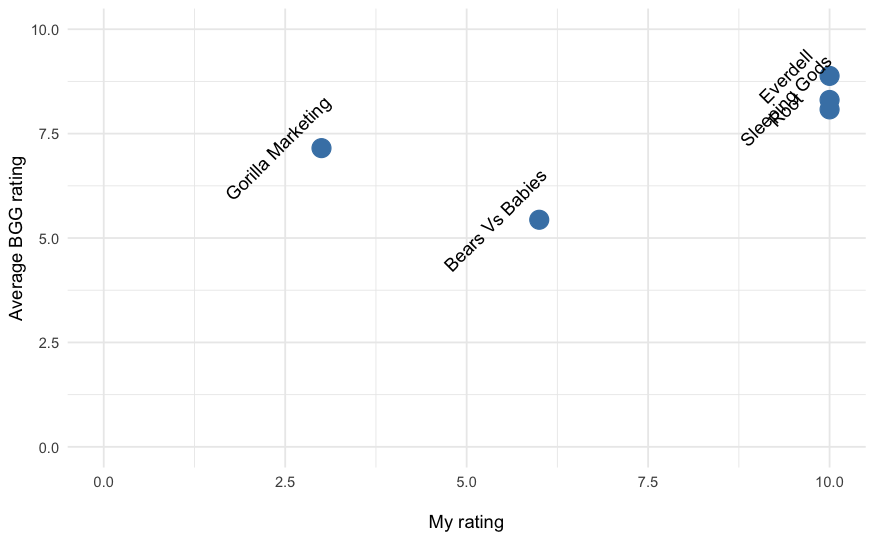

```r
bg_data %>%
  filter(boardgame %in% c("Everdell: The Complete Collection",
                          "Root", "Sleeping Gods", "Gorilla Marketing",
                          "Bears Vs Babies")) %>%
  mutate(boardgame = if_else(str_detect(boardgame, "Everdell"),
                                         "Everdell", boardgame)) %>%
  ggplot(aes(x = my_rating, y = average_bgg_rating)) +
  geom_point(colour = "steelblue", size = 5) +
  geom_text(aes(label = boardgame),
            nudge_x = -0.6, angle = 45) +
  xlim(c(0, 10)) +
  ylim(c(0, 10)) +
  labs(x = "\nMy rating",
       y = "Average BGG rating",
       ) +
  theme(text = element_text(size = 16)) +
  theme_minimal()
```

## How does this comparison look across all of my games?

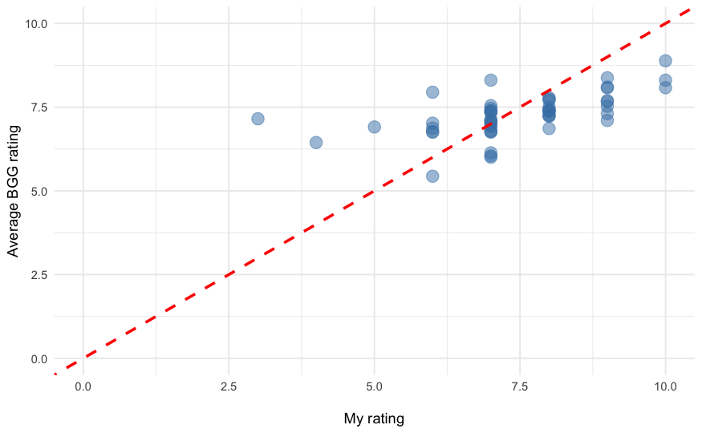

```r
bg_data %>%
  ggplot(aes(x = my_rating, y = average_bgg_rating)) +
  geom_point(colour = "steelblue", size = 4, alpha = 0.5) +
  xlim(c(0, 10)) +
  ylim(c(0, 10)) +
  labs(x = "\nMy rating",
       y = "Average BGG rating",
       ) +
  theme(text = element_text(size = 16)) +
  theme_minimal() +
  geom_abline(intercept = 0, slope = 1,
              linetype = "dashed", colour = "red",
              size = 1)
```

Looks fairly correlated. Let’s find a value:

```r
library(corrr)

# bg_data %>%
#   corrr::correlate() %>%
#   corrr::network_plot(colors = c("red", "green"))
#   cor(my_rating, average_bgg_rating)

bg_data %>%
  drop_na(my_rating) %>%
  summarise(correlation = cor(my_rating, average_bgg_rating))
```

| correlation |
| --- |
| 0.5839789 |

A correlation of 0.58 - fairly strong but nothing to write home about. Can see that I rank poorer games lower than the BGG average and better games higher than the average.

## How do my games fair in the overall Boardgamegeek ranking?

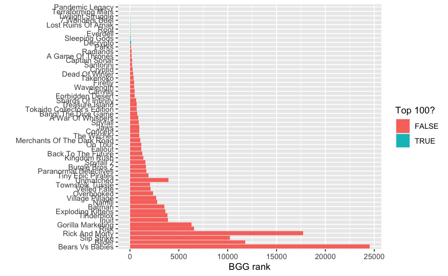

```r
bg_data %>%
  # removing anything after a colon to save space
  mutate(boardgame = case_when(
    str_detect(boardgame, ":") ~ str_extract(boardgame, "(.+): ", group = 1),
    .default = boardgame)) %>%
  mutate(top_100 = if_else(bgg_rank <= 100, TRUE, FALSE)) %>%
  ggplot() +
  geom_col(aes(x = reorder(boardgame, -bgg_rank), y = bgg_rank, fill = top_100)) +
  coord_flip() +
  labs(y = "BGG rank",
       x = "",
       fill = "Top 100?")
```

```r
bg_data %>%
  mutate(top_100 = if_else(bgg_rank <= 100, TRUE, FALSE)) %>%
  group_by(top_100) %>%
  summarise(prop_in_top_100 = n() / nrow(bg_data) * 100)
```

| top_100 | prop_in_top_100 |
| --- | --- |
| FALSE | 84.21053 |
| TRUE | 15.78947 |

```r
NA
```

Approximately 16% of my boardgames are in the top ranked 100.

Just those games in the top 1000:

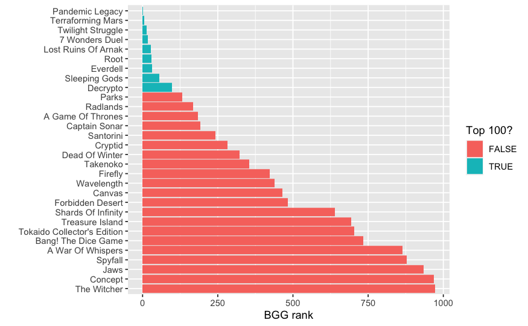

```r
bg_data %>%
  filter(bgg_rank <= 1000) %>%
  # removing anything after a colon to save space
  mutate(boardgame = case_when(
    str_detect(boardgame, ":") ~ str_extract(boardgame, "(.+): ", group = 1),
    .default = boardgame)) %>%
  mutate(top_100 = if_else(bgg_rank <= 100, TRUE, FALSE)) %>%
  ggplot() +
  geom_col(aes(x = reorder(boardgame, -bgg_rank), y = bgg_rank, fill = top_100)) +
  coord_flip() +
  labs(y = "BGG rank",
       x = "",
       fill = "Top 100?")
```

## Number of players

Does the number of recommended players for a game affect my enjoyment of it?

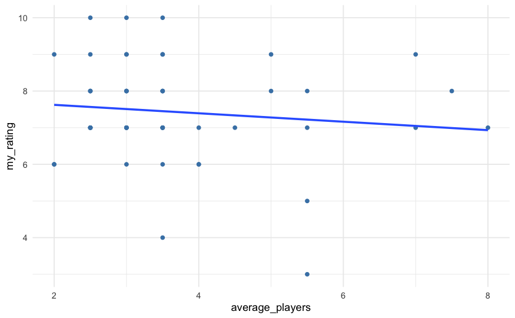

```r
bg_data %>%
  ggplot(aes(x = average_players, y = my_rating)) +
  geom_point(colour = "steelblue") +
  geom_smooth(method = "lm", se = FALSE) +
  theme_minimal()
```

Quite a mixed spread with no real trend.

### Clustering

Wrangle and scale the data:

```r
players_ratings <- bg_data %>%
  select(my_rating, average_players) %>%
  drop_na()

players_ratings_scaled <- players_ratings %>%
  mutate_if(is.numeric, scale)   # scale values

players_ratings
```

| my_rating | average_players |
| --- | --- |
| 9 | 2.0 |
| 7 | 3.0 |
| 8 | 3.0 |
| 5 | 5.5 |
| 6 | 3.5 |
| 7 | 7.0 |
| 8 | 2.5 |
| 7 | 3.0 |
| 9 | 5.0 |
| 7 | 8.0 |

[output cut: 41 more lines]

```r
NA
```

Create k-clusters of data:

```r
max_k <- 10 # max number of clusters to test

k_clusters <- tibble(k = 1:max_k) %>%
  mutate(
    kclust = map(k, ~ kmeans(players_ratings_scaled, .x, nstart = 25)),
   tidied = map(kclust, tidy),
    glanced = map(kclust, glance),
    augmented = map(kclust, augment, players_ratings)
  )

clusterings <- k_clusters %>%
  unnest(glanced)

clusterings
```

| k | kclust | tidied | totss | tot.withinss | betweenss | iter | augmented |
| --- | --- | --- | --- | --- | --- | --- | --- |
| 1 |  |  | 100 | 100.000000 | 5.684342e-14 | 1 |  |
| 2 |  |  | 100 | 61.378603 | 3.862140e+01 | 1 |  |
| 3 |  |  | 100 | 37.777688 | 6.222231e+01 | 2 |  |
| 4 |  |  | 100 | 23.752092 | 7.624791e+01 | 2 |  |
| 5 |  |  | 100 | 18.833741 | 8.116626e+01 | 2 |  |
| 6 |  |  | 100 | 14.682231 | 8.531777e+01 | 2 |  |
| 7 |  |  | 100 | 11.735804 | 8.826420e+01 | 2 |  |
| 8 |  |  | 100 | 10.446955 | 8.955304e+01 | 3 |  |
| 9 |  |  | 100 | 9.026756 | 9.097324e+01 | 2 |  |
| 10 |  |  | 100 | 8.088149 | 9.191185e+01 | 3 |  |

Plot the number of clusters with total within SSs:

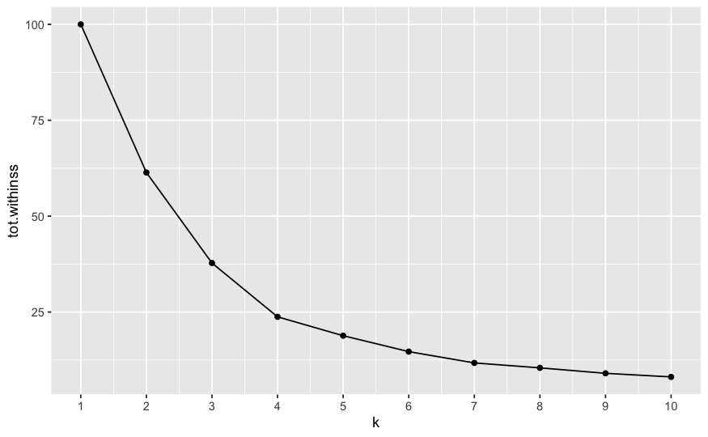

```r
ggplot(clusterings, aes(x=k, y=tot.withinss)) +
  geom_point() +
    geom_line() +
    scale_x_continuous(breaks = seq(1, 10, by = 1))
```

k = 4 seems to be a good kink in the elbow, so 4 clusters is sensible.

Can also see this with:

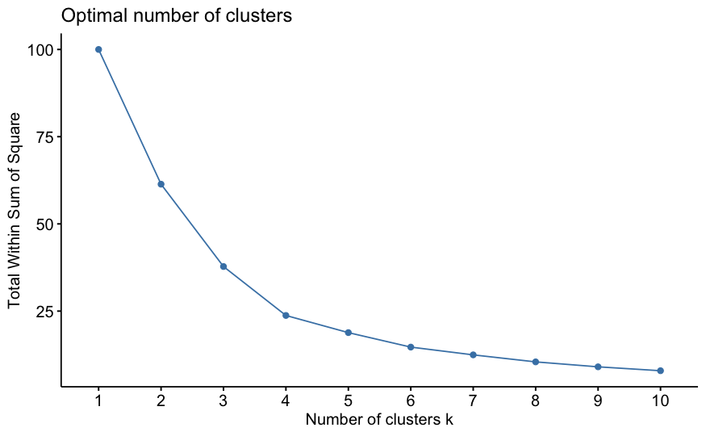

```r
library(factoextra)
fviz_nbclust(players_ratings_scaled,
             kmeans,
             method = "wss",
             nstart = 25)
```

Let’s visualise the clusters:

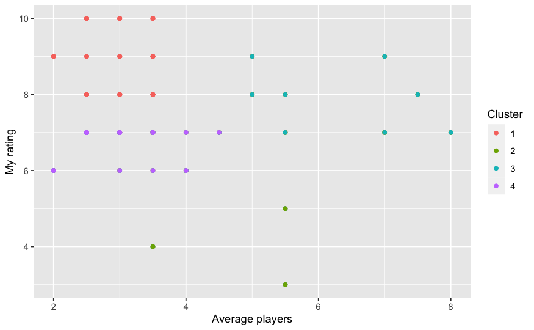

```r
players_cluster_plot <- clusterings %>%
  unnest(cols = c(augmented)) %>%
  filter(k <= 4) %>%
  ggplot(aes(x = average_players, y = my_rating)) +
  geom_point(aes(colour = .cluster)) +
  labs(x = "Average players",
       y = "My rating",
       colour = "Cluster")

players_cluster_plot
```

Will add points to the scatterplot to visualise cluster means:

```r
cluster_means <- clusterings %>%
  unnest(augmented) %>%
  filter(k == 4) %>%
  group_by(.cluster) %>%
  summarise(mean_players = mean(average_players), mean_rating = mean(my_rating)) %>%
  select(-.cluster)

cluster_means
```

| mean_players | mean_rating |
| --- | --- |
| 2.972222 | 8.666667 |
| 4.833333 | 4.000000 |
| 6.312500 | 7.875000 |
| 3.113636 | 6.727273 |

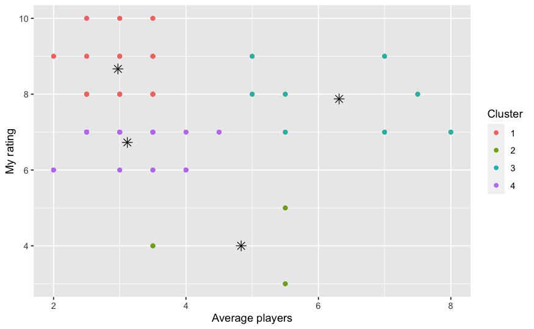

```r
players_cluster_plot +
  geom_point(data = cluster_means,
             aes(x = mean_players, y = mean_rating),
             colour = "black", shape = 8, size = 3)
```

```r
NA
```

Cluster 2 seems to represent the games that can accommodate medium-sized groups that I don’t enjoy very much.

Cluster 3 seems to represent the party games that can play with large groups that I enjoy very much - e.g. Wavelength.

Cluster 4 contains those games for smaller groups that I find pretty good.

Cluster 1 contains the games for the smallest groups that I find excellent.

## Play time

Does the play time of a game affect my enjoyment of it?

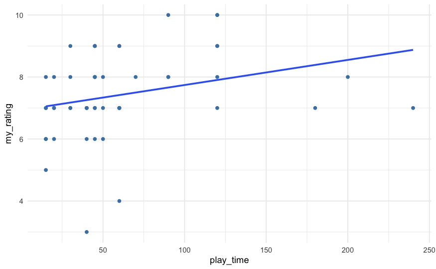

```r
bg_data %>%
  ggplot(aes(x = play_time, y = my_rating)) +
  geom_point(colour = "steelblue") +
  geom_smooth(method = "lm", se = FALSE) +
  theme_minimal()
```

There seems to be a slight positive relationship between the length of a game and how I rate it.

### Clustering

```r
playtime_ratings <- bg_data %>%
  select(my_rating, play_time) %>%
  drop_na()

playtime_ratings_scaled <- playtime_ratings %>%
  mutate_if(is.numeric, scale)   # scale values

playtime_ratings
```

| my_rating | play_time |
| --- | --- |
| 9 | 30 |
| 7 | 60 |
| 8 | 50 |
| 5 | 15 |
| 6 | 20 |
| 7 | 60 |
| 8 | 70 |
| 7 | 30 |
| 9 | 60 |
| 7 | 40 |

[output cut: 41 more lines]

```r
NA
```

Create clusters:

```r
max_k <- 10 # max number of clusters to test

k_clusters <- tibble(k = 1:max_k) %>%
  mutate(
    kclust = map(k, ~ kmeans(playtime_ratings_scaled, .x, nstart = 25)),
   tidied = map(kclust, tidy),
    glanced = map(kclust, glance),
    augmented = map(kclust, augment, playtime_ratings)
  )

clusterings <- k_clusters %>%
  unnest(glanced)

clusterings
```

| k | kclust | tidied | totss | tot.withinss | betweenss | iter | augmented |
| --- | --- | --- | --- | --- | --- | --- | --- |
| 1 |  |  | 100 | 100.000000 | 1.421085e-13 | 1 |  |
| 2 |  |  | 100 | 56.804290 | 4.319571e+01 | 1 |  |
| 3 |  |  | 100 | 36.547760 | 6.345224e+01 | 2 |  |
| 4 |  |  | 100 | 24.643793 | 7.535621e+01 | 2 |  |
| 5 |  |  | 100 | 16.044976 | 8.395502e+01 | 2 |  |
| 6 |  |  | 100 | 12.027839 | 8.797216e+01 | 2 |  |
| 7 |  |  | 100 | 9.041282 | 9.095872e+01 | 3 |  |
| 8 |  |  | 100 | 7.182677 | 9.281732e+01 | 2 |  |
| 9 |  |  | 100 | 5.897639 | 9.410236e+01 | 2 |  |
| 10 |  |  | 100 | 5.058711 | 9.494129e+01 | 2 |  |

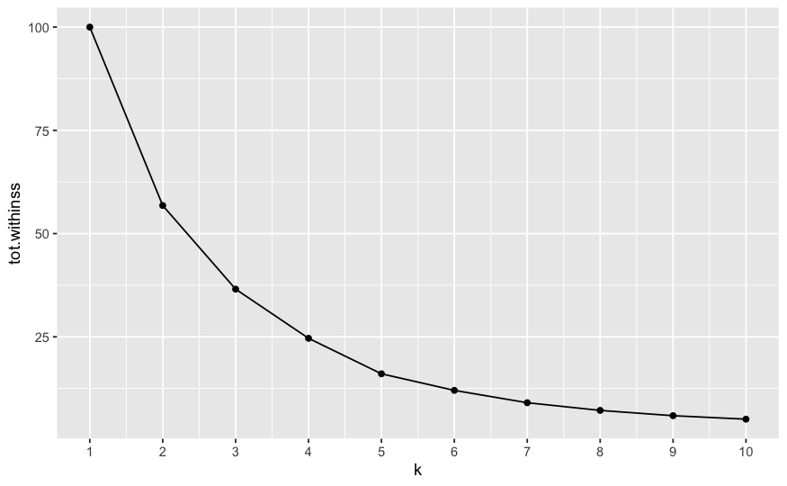

```r
ggplot(clusterings, aes(x=k, y=tot.withinss)) +
  geom_point() +
    geom_line() +
    scale_x_continuous(breaks = seq(1, 10, by = 1))
```

k = 4 or 5 seems to be a good kink in the elbow, so 4 clusters is sensible.

Can also see this with:

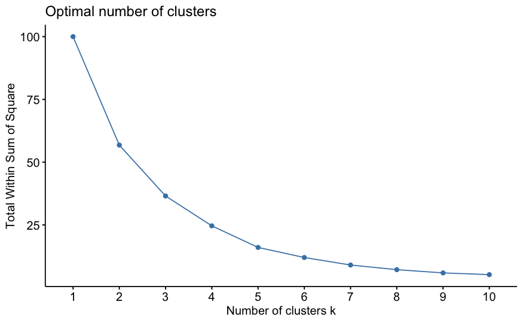

```r
library(factoextra)

fviz_nbclust(playtime_ratings_scaled,
             kmeans,
             method = "wss",
             nstart = 25)
```

Let’s visualise the clusters:

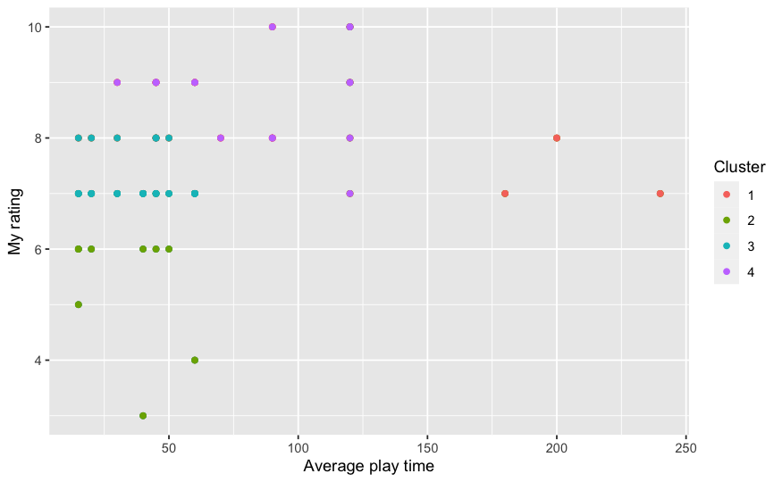

```r
playtime_cluster_plot <- clusterings %>%
  unnest(cols = c(augmented)) %>%
  filter(k <= 4) %>%
  ggplot(aes(x = play_time, y = my_rating)) +
  geom_point(aes(colour = .cluster)) +
  labs(x = "Average play time",
       y = "My rating",
       colour = "Cluster")

playtime_cluster_plot
```

Will add points to the scatterplot to visualise cluster means:

```r
cluster_means <- clusterings %>%
  unnest(augmented) %>%
  filter(k == 4) %>%
  group_by(.cluster) %>%
  summarise(mean_playtime = mean(play_time), mean_rating = mean(my_rating)) %>%
  select(-.cluster)

cluster_means
```

| mean_playtime | mean_rating |
| --- | --- |
| 206.66667 | 7.333333 |
| 33.33333 | 5.333333 |
| 38.26087 | 7.304348 |
| 84.06250 | 8.812500 |

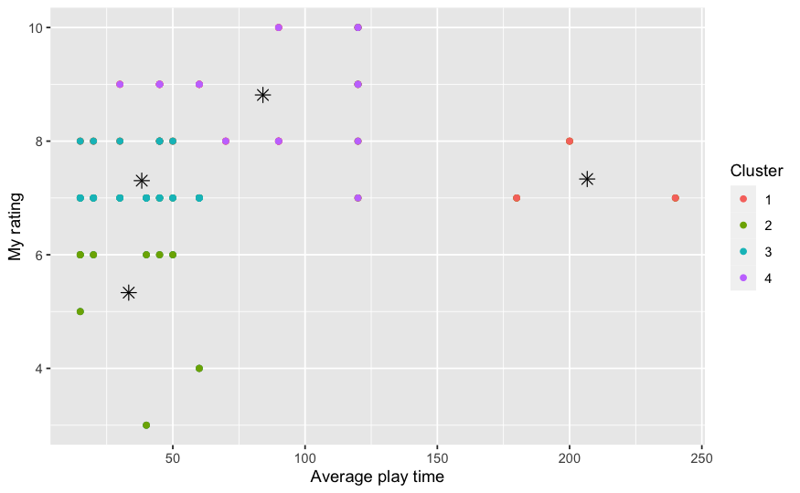

```r
playtime_cluster_plot +
  geom_point(data = cluster_means,
             aes(x = mean_playtime, y = mean_rating),
             colour = "black", shape = 8, size = 3)
```

```r
NA
```

Cluster 2 is the short games I find okay (like little party games I’d expect)

Cluster 3 is the short games I really enjoy such as Back to the Future, Bilder, Decrypto.

```r
bg_data %>%
  filter(my_rating > 6 & my_rating <= 8) %>%
  filter(play_time < 75)
```

| boardgame | average_bgg_rating | average_difficulty | bgg_rank | num_owned | play_time | max_players | min_players | rec_age_range_from | average_players | price_i_paid | my_rating | year_bought |
| --- | --- | --- | --- | --- | --- | --- | --- | --- | --- | --- | --- | --- |
| A War Of Whispers | 7.35921 | 2.5248 | 864 | 5810 | 60 | 4 | 2 | 12 | 3.0 | 34 | 7 | 2021 |
| Back To The Future: Back In Time | 7.26414 | 2.3871 | 1292 | 6587 | 50 | 4 | 2 | 8 | 3.0 | 32 | 8 | 2021 |
| Bilder | 6.75184 | 2.0000 | 11823 | 173 | 60 | 12 | 2 | 8 | 7.0 | 47 | 7 | 2020 |
| Burgle Bros 2: The Casino Capers | 7.37987 | 2.4865 | 1655 | 4909 | 70 | 4 | 1 | 10 | 2.5 | 37 | 8 | 2021 |
| Canvas | 7.33133 | 1.6471 | 465 | 18300 | 30 | 5 | 1 | 8 | 3.0 | 44 | 7 | 2021 |
| Concept | 6.77148 | 1.3817 | 968 | 30783 | 40 | 12 | 4 | 10 | 8.0 | 19 | 7 | 2019 |
| Cryptid | 7.46266 | 2.2362 | 282 | 17760 | 50 | 5 | 3 | 10 | 4.0 | 21 | 7 | 2019 |
| Decrypto | 7.77892 | 1.8118 | 97 | 31448 | 45 | 8 | 3 | 10 | 5.5 | 16 | 8 | 2018 |
| Exploding Kittens | 6.04801 | 1.0901 | 3607 | 65893 | 15 | 5 | 2 | 8 | 3.5 | NA | 7 | 2015 |
| Forbidden Desert | 7.08973 | 2.0382 | 482 | 51794 | 45 | 5 | 2 | 8 | 3.5 | 17 | 7 | 2015 |

[output cut: 14 more lines]

Cluster 4 is the sweet spot: amazing games that don’t take all day (Captain Sonar, Everdell, Lost Ruins of Arnak)

```r
bg_data %>%
  filter(my_rating >= 8) %>%
  filter(play_time < 125 & play_time > 50)
```

| boardgame | average_bgg_rating | average_difficulty | bgg_rank | num_owned | play_time | max_players | min_players | rec_age_range_from | average_players | price_i_paid | my_rating | year_bought |
| --- | --- | --- | --- | --- | --- | --- | --- | --- | --- | --- | --- | --- |
| Burgle Bros 2: The Casino Capers | 7.37987 | 2.4865 | 1655 | 4909 | 70 | 4 | 1 | 10 | 2.5 | 37 | 8 | 2021 |
| Captain Sonar | 7.52558 | 2.1821 | 193 | 27974 | 60 | 8 | 2 | 12 | 5.0 | 33 | 9 | 2018 |
| Everdell: The Complete Collection | 8.88292 | 3.0000 | 31 | 8148 | 120 | 6 | 1 | 14 | 3.5 | 182 | 10 | 2022 |
| Kingdom Rush: Rift In Time | 7.38356 | 2.9744 | 1396 | 5349 | 90 | 4 | 1 | 10 | 2.5 | 112 | 8 | 2020 |
| Lost Ruins Of Arnak | 8.07930 | 2.9019 | 28 | 54248 | 120 | 4 | 1 | 10 | 2.5 | 46 | 9 | 2021 |
| Merchants Of The Dark Road | 7.42507 | 3.1806 | 1041 | 6276 | 120 | 4 | 1 | 12 | 2.5 | 101 | 8 | 2022 |
| Parks | 7.69390 | 2.1439 | 131 | 38432 | 60 | 5 | 1 | 10 | 3.0 | 35 | 9 | 2019 |
| Root | 8.08015 | 3.7723 | 29 | 68243 | 90 | 4 | 2 | 12 | 3.0 | 116 | 10 | 2020 |
| Sleeping Gods | 8.30626 | 3.2277 | 55 | 22032 | 120 | 4 | 1 | 10 | 2.5 | 85 | 10 | 2021 |
| Terraforming Mars | 8.37605 | 3.2588 | 6 | 125751 | 120 | 5 | 1 | 12 | 3.0 | 44 | 9 | 2020 |

[output cut: 1 more lines]

## Linear regression model

```r
library(modelr)
library(GGally)
library(ggfortify)
```

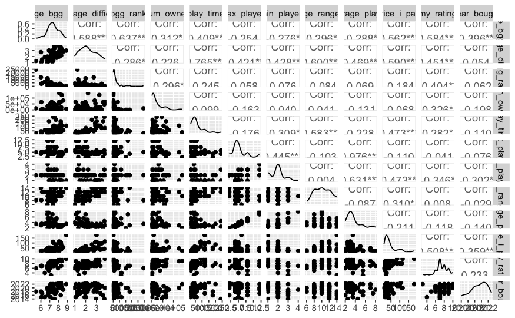

```r
bg_data %>%
  select(-boardgame) %>%
  ggpairs(progress = FALSE)
```

Contenders are: * average_bgg_rating * price_i_paid * average_difficulty * min_players

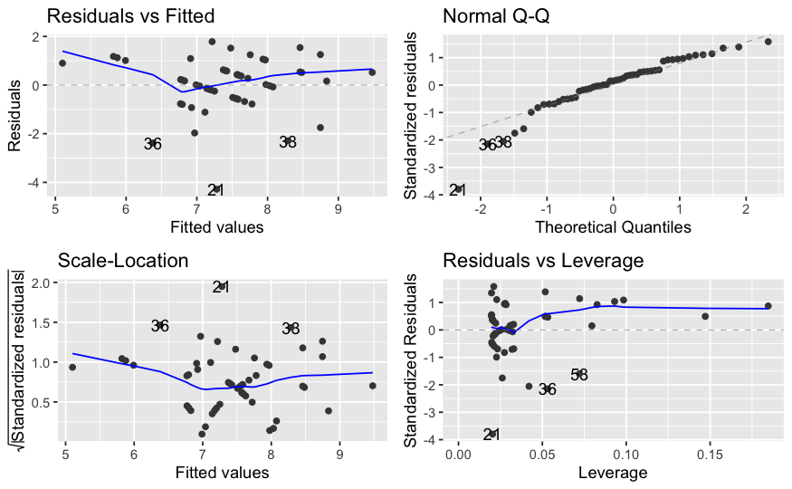

```r
bg_model1 <- lm(my_rating ~ average_bgg_rating, data = bg_data)


autoplot(bg_model1) # look okay
```

```r
summary(bg_model1)
```

```
Call:
lm(formula = my_rating ~ average_bgg_rating, data = bg_data)

Residuals:
    Min      1Q  Median      3Q     Max
-4.2806 -0.5573  0.1728  0.6146  1.7841

Coefficients:
                   Estimate Std. Error t value Pr(>|t|)
(Intercept)         -1.8103     1.8421  -0.983    0.331
average_bgg_rating   1.2710     0.2524   5.036 6.84e-06 ***
---
Signif. codes:  0 ‘***’ 0.001 ‘**’ 0.01 ‘*’ 0.05 ‘.’ 0.1 ‘ ’ 1

Residual standard error: 1.139 on 49 degrees of freedom
  (6 observations deleted due to missingness)
Multiple R-squared:  0.341, Adjusted R-squared:  0.3276
F-statistic: 25.36 on 1 and 49 DF,  p-value: 6.843e-06
```

Looks like average_bgg_rating is a good predictor of my own rating!

Let’s add more predictors:

```r
bg_model2 <- lm(my_rating ~ average_bgg_rating + price_i_paid , data = bg_data)
```

[output not shown]

```r
bg_model2 <- lm(my_rating ~ average_bgg_rating + average_difficulty , data = bg_data)


autoplot(bg_model2) # look okay

summary(bg_model2)
```

[output not shown]

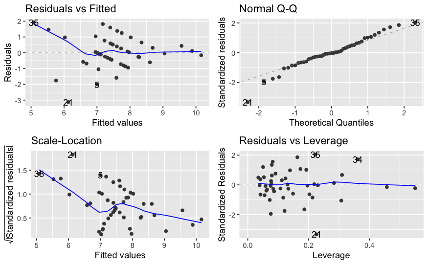

```r
bg_model_final <- lm(my_rating ~ average_bgg_rating + average_difficulty + price_i_paid + average_players + play_time + rec_age_range_from, data = bg_data)


autoplot(bg_model_final) # look okay
```

```r
summary(bg_model_final)
```

```
Call:
lm(formula = my_rating ~ average_bgg_rating + average_difficulty +
    price_i_paid + average_players + play_time + rec_age_range_from,
    data = bg_data)

Residuals:
     Min       1Q   Median       3Q      Max
-3.13027 -0.51246 -0.02615  0.56642  1.91786

Coefficients:
                    Estimate Std. Error t value Pr(>|t|)
(Intercept)        -1.593401   2.797042  -0.570  0.57208
average_bgg_rating  1.114963   0.366290   3.044  0.00412 **
average_difficulty  0.965406   0.471437   2.048  0.04718 *
price_i_paid        0.007929   0.006728   1.178  0.24558
average_players     0.219935   0.144751   1.519  0.13653
play_time          -0.003327   0.004850  -0.686  0.49665
rec_age_range_from -0.204407   0.094308  -2.167  0.03621 *
---
Signif. codes:  0 ‘***’ 0.001 ‘**’ 0.01 ‘*’ 0.05 ‘.’ 0.1 ‘ ’ 1

Residual standard error: 1.071 on 40 degrees of freedom
  (10 observations deleted due to missingness)
Multiple R-squared:    0.5, Adjusted R-squared:  0.425
F-statistic: 6.667 on 6 and 40 DF,  p-value: 6.054e-05
```

Model explains almost half of the variance in my ratings. Seems that the:

- BGG average rating has a positive relationship with my rating (+1 in BGG rating leads to +1.11 in my rating)
- the difficulty has a positive relationship with my rating (+ 1 in difficulty/weight leads to + 0.97 in my rating)
- The recommended ages (i.e. ages x and above) has a negative relationship with my rating (+ 1 in age leads to -0.20 in my rating)

The other predictors are not significant.

Interesting that I like games that are more difficult but not games for older players. Less interesting that I rate games higher if they’re rated higher on BGG.

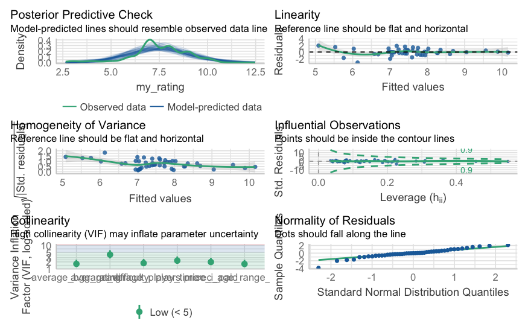